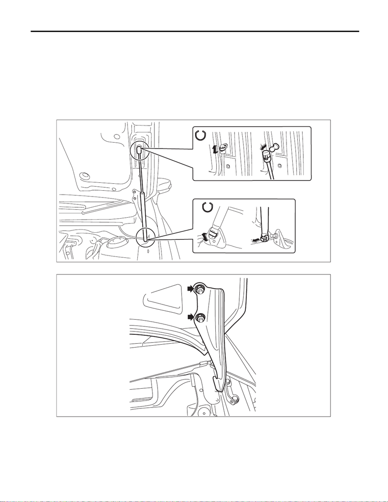

EB-10

Front Hood

EXTERIOR BODY PANELS

2. Front Hood

A: REMOVAL

CAUTION:

The hood COMPL - front is heavy. When removing and installing it, always work in a team of two or

more persons.

1) Open the hood COMPL - front.

2) Remove the stay assembly - front hood.

(1) Float the lock pin using a flat tip screwdriver, etc. and slide it.

(2) Pull the mounting point of the stay assembly - front hood, and remove the stay assembly - front hood.

3) Remove the nut on the hood COMPL - front side, and remove the hood COMPL - front.

EB-00958

EB-00689

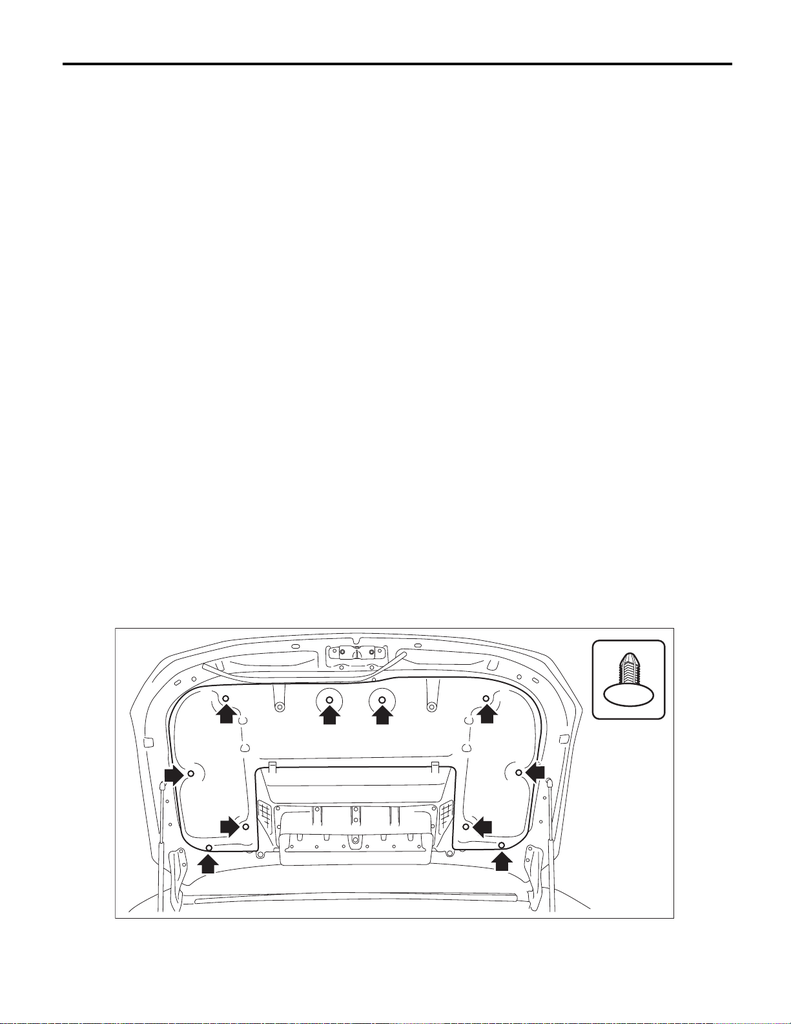

EB-11

Front Hood

EXTERIOR BODY PANELS

B: INSTALLATION

NOTE:

When the hood COMPL - front is replaced, adhere the label on the same position.

1) Temporarily fit the hinge COMPL - front hood around the original position on the vehicle body.

2) Install the hood COMPL - front to the hinge COMPL - front hood.

Tightening torque:

25 N·m (2.5 kgf-m, 18.4 ft-lb)

3) Install the stay assembly - front hood.

4) When temporarily fitting the fender COMPL - front and adjusting the clearance, make sure that a uniform

clearance is created around the hood COMPL - front.

NOTE:

When installing the fender COMPL - front, make sure that a uniform clearance is created around it.

• Fender COMPL - front to Hood COMPL - front: <Ref. to EB-17, ADJUSTMENT, Front Hood.>

• Fender COMPL - front to Panel assembly - front door: <Ref. to EB-30, ADJUSTMENT, Front Door.>

5) Install the hinge COMPL - front hood.

(1) Tighten the bolts at the front side, and temporarily fit the bolts at the rear side.

(2) Remove the fender COMPL - front, and tighten to the specified torque.

Tightening torque:

25 N·m (2.5 kgf-m, 18.4 ft-lb)

6) Readjust the fender COMPL - front to install.

NOTE:

When installing the fender COMPL - front, make sure that a uniform clearance is created around it.

• Fender COMPL - front to Hood COMPL - front: <Ref. to EB-17, ADJUSTMENT, Front Hood.>

• Fender COMPL - front to Panel assembly - front door: <Ref. to EB-30, ADJUSTMENT, Front Door.>

C: DISASSEMBLY

CAUTION:

• Do not damage piston rods and oil seals.

• Never disassemble cylinders: They contain gas.

• The hood COMPL - front is heavy. When removing or installing the hood COMPL - front, stay as-

sembly - front hood, and hinge COMPL - front hood, be sure to work in a team of two or more persons.

1) Remove the clips, and remove the insulator - front hood.

EI-04288

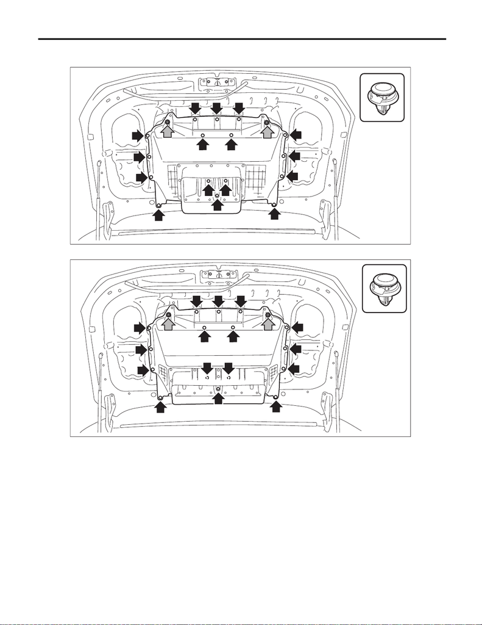

EB-12

Front Hood

EXTERIOR BODY PANELS

2) Remove the clips and bolts, and remove the duct - inner front hood.

• Except for STI model

• STI model

EI-04289

EI-04290

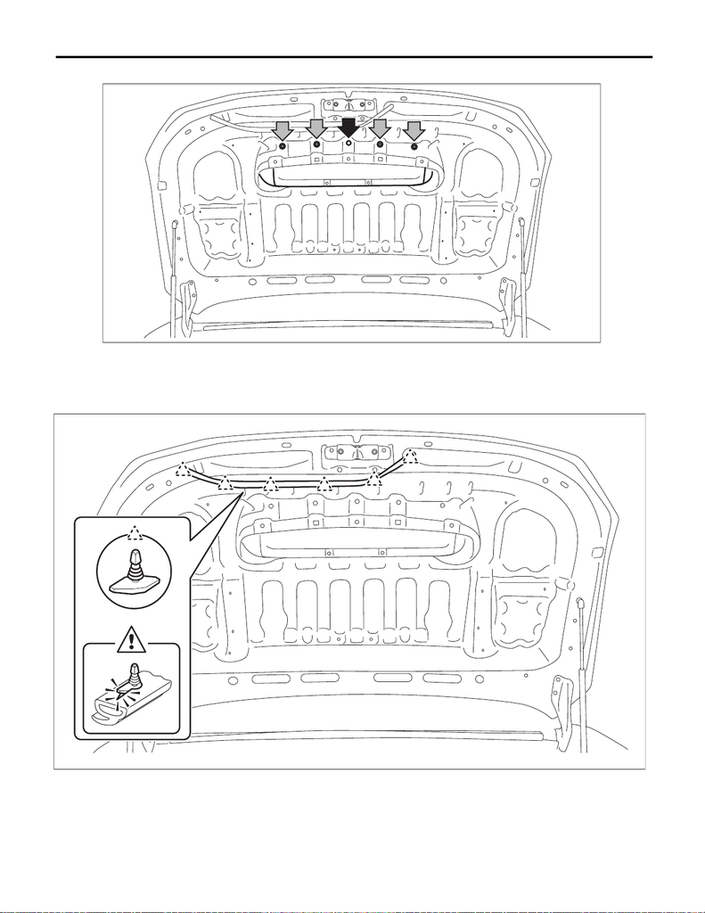

EB-13

Front Hood

EXTERIOR BODY PANELS

3) Remove the bolts, release the clips, and then remove the duct - outer front hood.

4) Remove the clip, and remove the seal - front duct.

CAUTION:

If the weather strip clip is removed with excessive force, the seal - front duct may be damaged. Be

sure to use clip remover, etc. to remove.

EI-04302

EB-00960

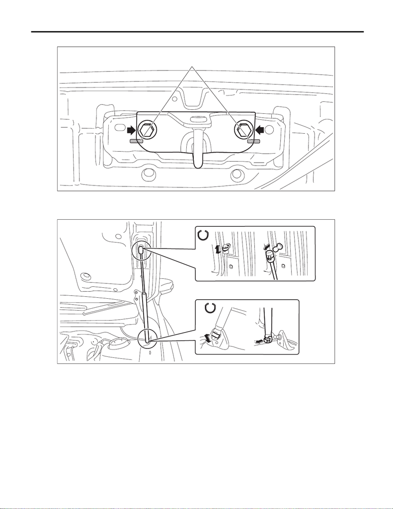

EB-14

Front Hood

EXTERIOR BODY PANELS

5) Make alignment marks (A), and remove the striker - front hood from the hood COMPL - front.

6) Remove the stay assembly - front hood from the body.

(1) Float the lock pin using a flat tip screwdriver, etc. and slide it.

(2) Pull the mounting point of the stay assembly - front hood, and remove the stay assembly - front hood.

(A)

EB-00959

EB-00958

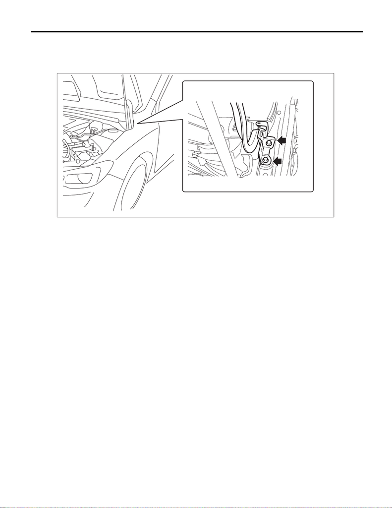

EB-15

Front Hood

EXTERIOR BODY PANELS

7) Remove the hinge COMPL - front hood from the body.

NOTE:

The hinge COMPL - front hood cannot be removed with the fender COMPL - front attached. Therefore, re-

move the fender COMPL - front beforehand.

D: ASSEMBLY

1) Install the hinge COMPL - front hood.

Tightening torque:

25 N·m (2.5 kgf-m, 18.4 ft-lb)

2) Install the stay assembly - front hood.

Tightening torque:

20 N·m (2.0 kgf-m, 14.8 ft-lb)

3) Install the seal - front duct.

4) Install the duct - outer front hood.

Tightening torque:

4.5 N·m (0.5 kgf-m, 3.3 ft-lb)

EB-00961

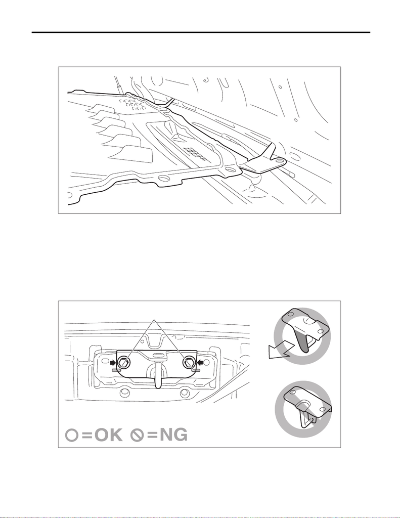

EB-16

Front Hood

EXTERIOR BODY PANELS

5) Install the duct - inner front hood.

NOTE:

Securely insert the claws of the front hood duct.

6) Install the insulator - front hood.

7) Align the alignment marks (A), and install the striker - front hood to the hood COMPL - front.

CAUTION:

When installing the striker - front hood, make sure that the front and rear sides are positioned in a

correct direction.

NOTE:

It is not necessary to adjust the striker - front hood because there is no span of adjustable range.

Tightening torque:

33 N·m (3.4 kgf-m, 24.3 ft-lb)

EI-04304

EB-00962

F

(A)

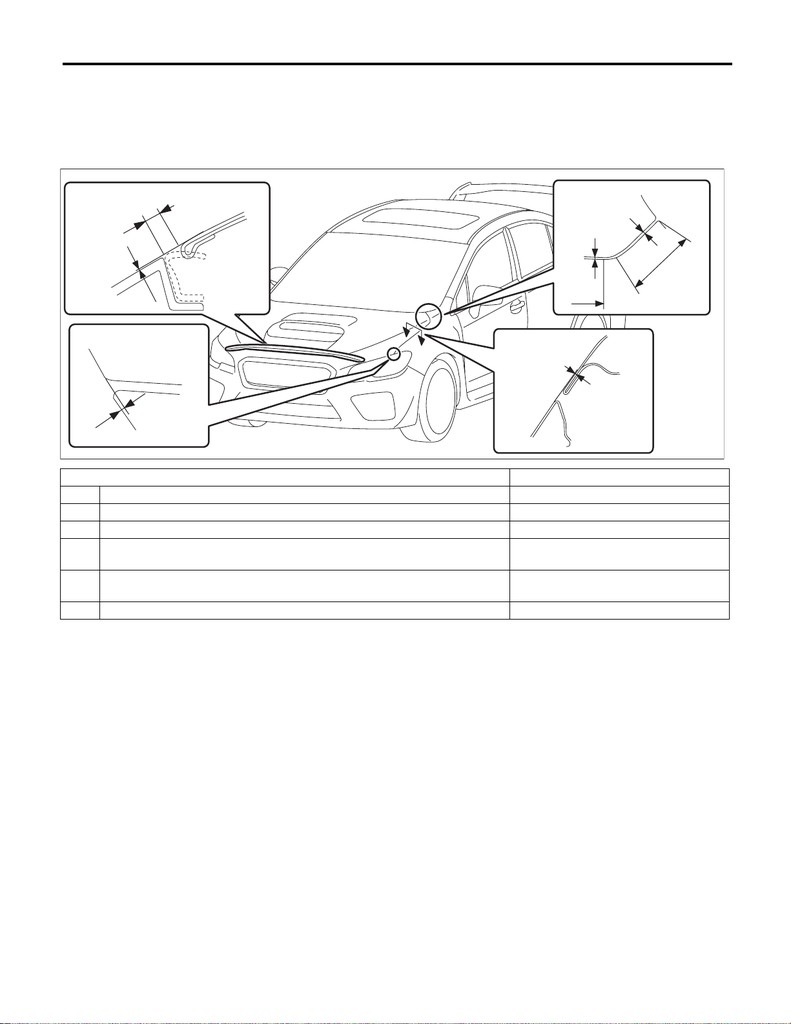

EB-17

Front Hood

EXTERIOR BODY PANELS

E: ADJUSTMENT

NOTE:

Adjustment should be performed on the fender COMPL - front, lock assembly - front hood and buffer - front

hood, because adjustment cannot be performed on the hinge COMPL - front hood.

Adjust the clearance around the hood COMPL - front as follows.

1) Adjust the front end height of the hood COMPL - front. <Ref. to SL-54, ADJUSTMENT, Front Hood Lock

Assembly.>

Part Standard

A Hood COMPL - front to Bumper face front 4.5±2.0 mm (0.18±0.08 in)

B Surface level gap between Hood COMPL - front and Bumper face front 0+1.5, –2.0 mm (0+0.06, –0.08 in)

C Offset value: Hood COMPL - front to Front end of fender COMPL - front 0+0.5, –1.0 mm (0+0.02, –0.04 in)

D Hood COMPL - front to Fender COMPL - front (from front end to just before

curved portion)

3.5±1.0 mm (0.14±0.04 in)

E Hood COMPL - front to Fender COMPL - front (from rear end to just before

curved portion)

4.5±1.0 mm (0.18±0.04 in)

F Surface level gap: Hood COMPL - front to Fender COMPL - front 0.5+0.5, –1.0 mm (0.02+0.02, –0.04 in)

EB-00963

D

E

F

C

A

B

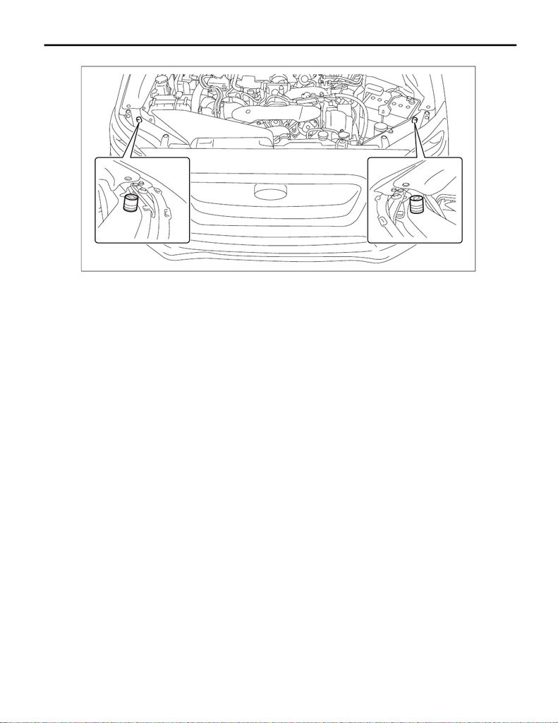

EB-18

Front Hood

EXTERIOR BODY PANELS

2) Rotate the buffer - front hood of the hood COMPL - front to adjust the height.

EB-00965